# Comparison Figures — Yogurt Study

## qPCR outcomes — faceted by outcome

Three bacterial DNA measures, split by study arm. Each panel shows one outcome, and `stat_compare_means()` draws the Wilcoxon p-value on the plot.

```r
# Pivot longer so we can facet by outcome name
qpcr_long <- qpcr |>
  pivot_longer(
    cols = c(qpcr_bacteria, qpcr_crispatus, qpcr_iners),
    names_to = "outcome",
    values_to = "value"
  ) |>
  # Clean up labels for the facet strips
  mutate(outcome = case_when(
    outcome == "qpcr_bacteria"  ~ "Total bacteria",
    outcome == "qpcr_crispatus" ~ "L. crispatus",
    outcome == "qpcr_iners"     ~ "L. iners"
  ))
```

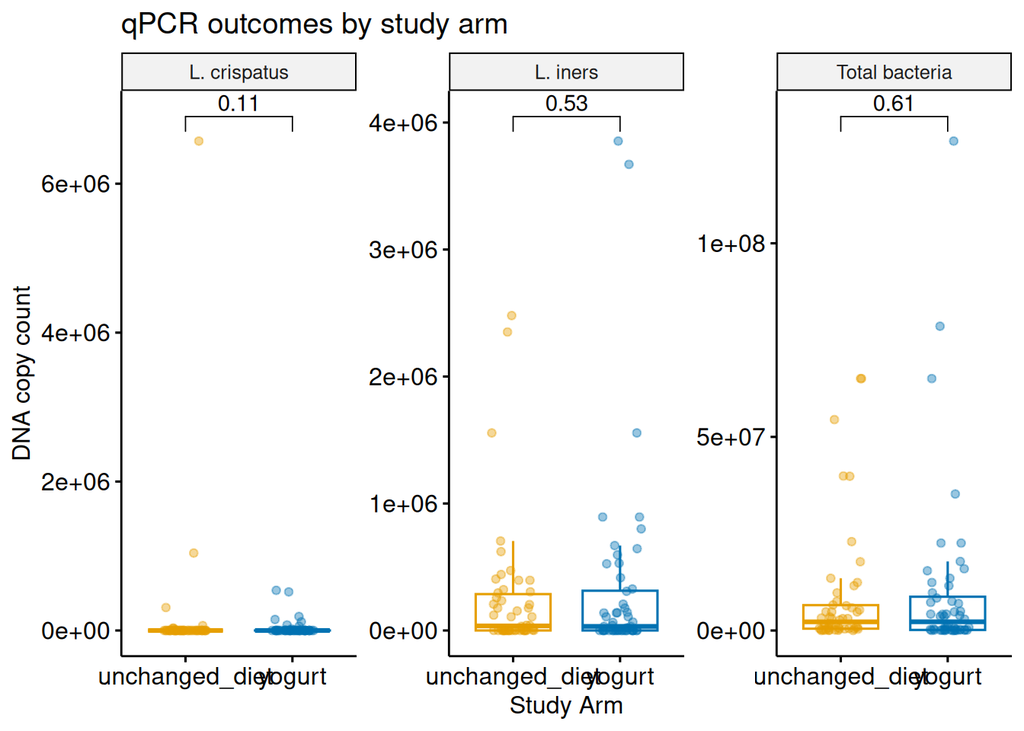

```r
ggpubr::ggboxplot(
  qpcr_long,
  x = "arm",
  y = "value",
  color = "arm",
  palette = c("#E69F00", "#0072B2"),
  add = "jitter",
  add.params = list(size = 1.5, alpha = 0.4)
) +
  facet_wrap(~ outcome, scales = "free_y") +
  stat_compare_means(comparisons = list(c("unchanged_diet", "yogurt")),
                     method = "wilcox.test",
                     label = "p.format") +
  labs(x = "Study Arm", y = "DNA copy count",
       title = "qPCR outcomes by study arm") +
  theme(legend.position = "none")
```

Looking at *L. crispatus* — notice how a few high-outlier samples stretch the y-axis. On the log scale, the pattern is clearer:

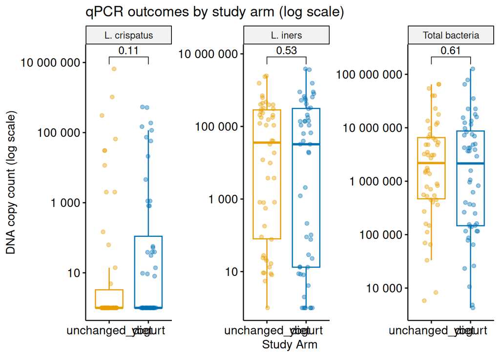

```r
ggpubr::ggboxplot(
  qpcr_long |> mutate(value = value + 1),  # +1 so log(0) = log(1) = 0
  x = "arm",
  y = "value",
  color = "arm",
  palette = c("#E69F00", "#0072B2"),
  add = "jitter",
  add.params = list(size = 1.5, alpha = 0.4)
) +
  facet_wrap(~ outcome, scales = "free_y") +
  scale_y_log10(labels = scales::label_number()) +
  stat_compare_means(comparisons = list(c("unchanged_diet", "yogurt")),
                     method = "wilcox.test",
                     label = "p.format") +
  labs(x = "Study Arm", y = "DNA copy count (log scale)",
       title = "qPCR outcomes by study arm (log scale)") +
  theme(legend.position = "none")
```

## Cytokine immune markers — faceted by cytokine

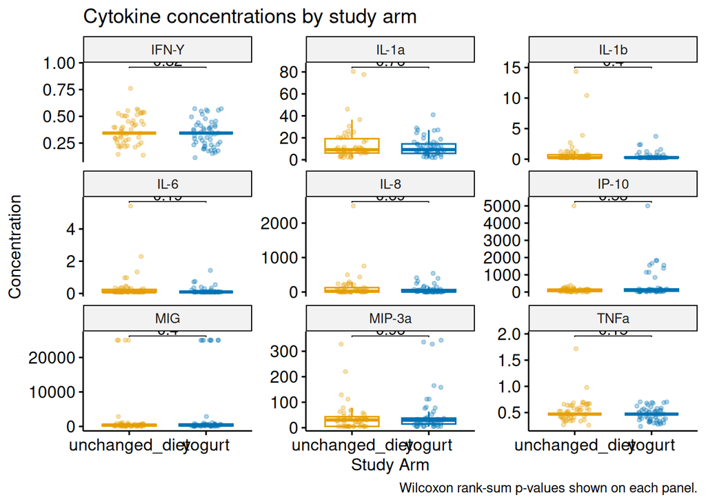

```r
# Data note: IL-10 is constant (0.767, all "out of range") — won't plot.

cytokines_valid <- c("IFN-Y", "TNFa", "IL-1a", "IL-1b", "IL-6", "IL-8", "IP-10", "MIG", "MIP-3a")

luminex |>
  filter(cytokine %in% cytokines_valid) |>
  ggboxplot(
    x = "arm",
    y = "conc",
    color = "arm",
    palette = c("#E69F00", "#0072B2"),
    add = "jitter",
    add.params = list(size = 1, alpha = 0.3)
  ) +
  facet_wrap(~ cytokine, scales = "free_y", nrow = 3) +
  stat_compare_means(comparisons = list(c("unchanged_diet", "yogurt")),
                     method = "wilcox.test",
                     label = "p.format",
                     tip.length = 0.01) +
  labs(x = "Study Arm", y = "Concentration",
       title = "Cytokine concentrations by study arm",
       caption = "Wilcoxon rank-sum p-values shown on each panel.") +
  theme(legend.position = "none")
```

Since cytokine data is often right-skewed, the log scale is more informative:

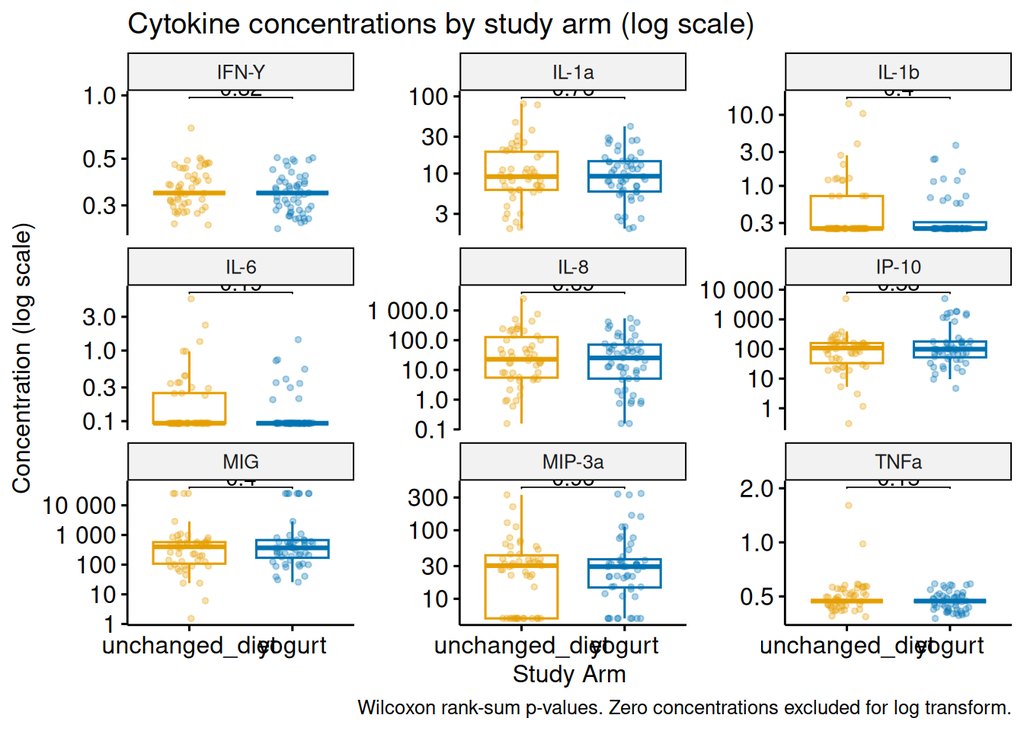

```r
luminex |>
  filter(cytokine %in% cytokines_valid, conc > 0) |>
  ggboxplot(
    x = "arm",
    y = "conc",
    color = "arm",
    palette = c("#E69F00", "#0072B2"),
    add = "jitter",
    add.params = list(size = 1, alpha = 0.3)
  ) +
  facet_wrap(~ cytokine, scales = "free_y", nrow = 3) +
  scale_y_log10(labels = scales::label_number()) +
  stat_compare_means(comparisons = list(c("unchanged_diet", "yogurt")),
                     method = "wilcox.test",
                     label = "p.format",
                     tip.length = 0.01) +
  labs(x = "Study Arm", y = "Concentration (log scale)",
       title = "Cytokine concentrations by study arm (log scale)",
       caption = "Wilcoxon rank-sum p-values. Zero concentrations excluded for log transform.") +
  theme(legend.position = "none")
```

## Data quality note

Cytokine data quality: how many measurements are ‘out of range’?

| cytokine | out of range | within limits | prop_unreliable |
| --- | --- | --- | --- |
| IFN-Y | 101 | 1 | 99 |
| IL-10 | 102 | 0 | 100 |
| IL-1a | 0 | 102 | 0 |
| IL-1b | 74 | 28 | 73 |
| IL-6 | 77 | 25 | 75 |
| IL-8 | 4 | 98 | 4 |
| IP-10 | 3 | 99 | 3 |
| MIG | 13 | 89 | 13 |
| MIP-3a | 24 | 78 | 24 |
| TNFa | 100 | 2 | 98 |

## Code summary

The pattern is always the same:

```r
library(ggpubr)

ggboxplot(data, x = "arm", y = "outcome",
          color = "arm", add = "jitter") +
  facet_wrap(~ group_var, scales = "free_y") +
  stat_compare_means(comparisons = list(c("group1", "group2")),
                     method = "wilcox.test",
                     label = "p.format")
```

- `ggboxplot()` — draws the boxplots with optional jittered points
- `facet_wrap()` — splits into multiple panels, one per outcome
- `stat_compare_means()` — adds the p-value; auto-chooses Wilcoxon for 2 groups or Kruskal-Wallis for 3+, or you can set `method = "t.test"`